# SOC 301 - 01

## Sample quiz question

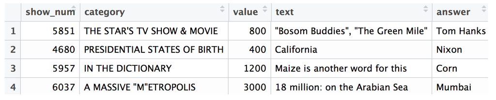

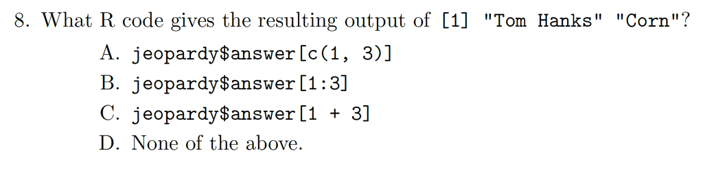

## Asking for help

- Recommended: Post your problem and drag a screenshot image of what you have tried to the #general channel on Slack.
- If you know the answer to a question there, please attempt to answer it. It will help you learn!
- Send me a private message on Slack (@chester)
- Discuss your problems with the tutors in person
- Last resort, send the tutors a private message on Slack

## You Should Learn to Program

[video not shown]

## Easy classes are worthless classes

- You won't retain any of the material covered
- You or someone else pays good money for you to get a good education here
- I want to do everything in my power to help you learn this material as I see it as THE MOST IMPORTANT class you can take as an undergraduate.
- You have many misconceptions about how you learn best. That's not your fault, but habits must be broken.
- Can we build muscles sitting on the couch?

## Why are you learning R?

- Because I enjoy partaking in Schadenfreude

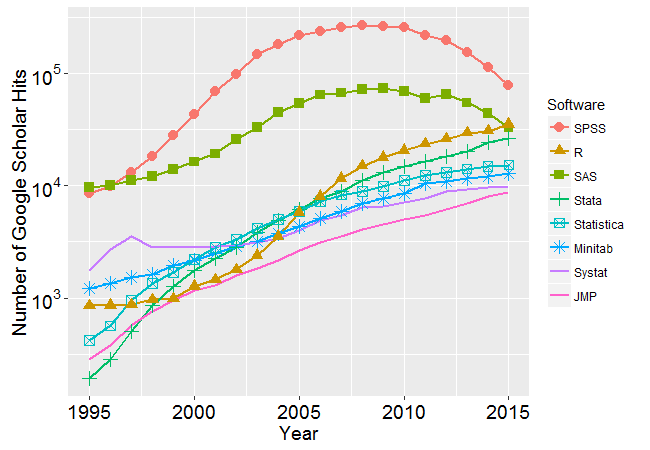

## Why are you learning R?

- R is free, R improves, R has been around for a long time
- You can show what you have learned to a potential employer easily
- I want to prepare you for the real world as best as I can and make you more employable than your competitors
- R will save you TONS of time in the long run. Long term thinking is key.
- You can easily tweak your code if you need to do another analysis
- Good luck trying to remember what drop-down menu some thing is in two years from now in a different program

## Reviewing R basics (on chalkboard)

## Key R functions/operators going forward

Operators

- `<-`
- `[]`
- `[ , ]`
- `$` (VERY IMPORTANT)
- `:`
- `<`, `>`, `<=`, `>=`
- `==`, `!=`
- `?`

## Key R functions/operators going forward

Functions

- `names()`
- `c()`
- `sum()`
- `mean()`
- `factor()`
  - `factor( , order = TRUE, levels = c( , , )`)
- `str()`
- `str()` `tibble::glimpse()`

## How should you prepare for the quiz?

[video not shown]

## How should you prepare for the quiz?

- [Advice from former students](http://ismayc.github.io/soc301_s2017/advice_from_former/index.html)
- Practice!

## Get into groups of 3 or 4

- Pass your multiple choice questions to someone else in your group
  - Take the "quiz" with no notes
  - Discuss your answers with your group
  - Take another "quiz"
  - Rinse and repeat

## Check the [webpage](https://ismayc.github.io/soc301_s2017/)!

## I want your feedback!

## To do for next time

- Study for Quiz #1 on Thursday, February 9 using the strategies laid out
  - The quiz will cover the Introduction to R DataCamp course
- Review the Learning Strategies given [here](http://www.learningscientists.org/posters) and commit to using them to succeed in learning
- Complete DataCamp profile
- Read Chapter 3 of [ModernDive](http://moderndive.com)
  - As you read attempt the Learning Checks for understanding
- Begin work on [Applying R Basics](https://campus.datacamp.com/courses/effective-data-storytelling-using-the-tidyverse/applying-r-basics?ex=1) DataCamp chapter (Due on February 14 at 1 PM)

## Minute Paper

(Half sheet of paper is fine. Share with your neighbor.)

- What are the big take-aways for you from class today?
- What questions do you have about the course? About the material you've learned so far?